# MATH 9102 - Probability and Statistical Inference Assignment - 2

Antonio Silva (D23129331@mytudublin.ie)

# Question 1 [1 mark]

A study was done in which the high daily temperature and the number of traffic accidents within the city were recorded. These sample data are shown as follows.

```
  temp <- c(91,56,75,68,50,39,98)
  accidents <- c(2,9,7,6,6,10,1)
  accTemp <- data.frame(temp, accidents)
```

Identify whether the data is positively correlated or negatively correlated using a scatter plot.

## Answer 1

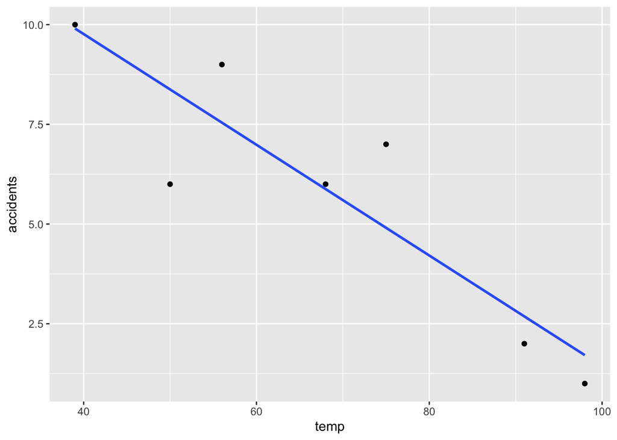

```r
temp <- c(91,56,75,68,50,39,98)
accidents <- c(2,9,7,6,6,10,1)
accTemp <- data.frame(temp, accidents)
ggplot(data = accTemp, aes(x = temp, y = accidents))  +
  geom_point() +
  geom_smooth(formula = y ~ x, method = "lm", se = FALSE)
```

After we create the scatter plot and and the trend line we can tell that the correlation is negative.

We can confirm calculating the correlation:

```r
cor(accTemp$temp, accTemp$accidents)
```

```
## [1] -0.8962298
```

# Question 2 [1 mark]

Following data gives the readings of sugar level of 5 diabetic patient before and after taking insulin. Using 1% level of significance test whether insulin has reduced sugar level.

```
  before <- c(350,400,250,200,180)
  after <- c(200,300,200,150,120)
```

## Answer 2

Because we are talking about related samples where the individual participants in single group measured at two different points the most suitable test is the *Paired samples t-test*.

For the test we have the following Hypothesis: * Null hypothesis: The insulin did not changed the sugar levels; * Alternative hypothesis: The insulin dropped the sugar levels.

So we will use the mean, because the measurements are taken from the same population, then they should fairly similar means.

The significance is 1%.

$$\begin{cases}
H_0: \mu_d \ge 0 \ or \ \mu_{after} - \mu_{before} \ge 0 \\
H_a: \mu_d < 0 \ or \ \mu_{after} - \mu_{before} < 0
\end{cases}$$

$$\alpha = 0.01$$

In R we can execute the test using the `t.test` function. This is a one-tail test from the left side.

So the Confidence Interval is $CI = 1 - \alpha = 0.99$

```r
  before <- c(350,400,250,200,180)
  after <- c(200,300,200,150,120)
  t.test(after, before, paired = TRUE, alternative = "less", conf.level = 0.99)
```

```
##
##  Paired t-test
##
## data:  after and before
## t = -4.2401, df = 4, p-value = 0.006631
## alternative hypothesis: true mean difference is less than 0
## 99 percent confidence interval:
##       -Inf -9.537486
## sample estimates:
## mean difference
##             -82
```

So we got the t-value of $-4.2401$ which is not in the $99\%$ region of acceptance: $[-3.747, \infty[$. So it is safe to say that we *Reject the null hypothesis* and conclude that the *insuline dropped the sugar levels*.

# Question 3 [2 marks]

The following dataset includes the score of students in mathematics and statistics. Justify with R code suitable correlation test. [Hint: Check for normality and test the data for correlation]

```
  maths <- c(50,54,56,59,60,62,61,65,67,71,71,74)
  stat <- c(22,25,34,28,26,30,32,30,28,34,36,40)
  scoreSet <- data.frame(maths, stat)
```

## Answer 3 [2 marks]

First we start inspecting the both dataset to see if they belong to a normal distribution. We can start by defining the data and create a Q-Q plot. As quoted in the labs of week 6:

> A Q-Q plot is a scatterplot created by plotting two sets of quantiles agains one another. If the both sets of quantiles come from the same distribution, we will see the points forming a line.

So to verify we can draw a Q-Q plot against the normal distribution first.

First we introduce the data

```r
maths <- c(50,54,56,59,60,62,61,65,67,71,71,74)
stat <- c(22,25,34,28,26,30,32,30,28,34,36,40)
scoreSet <- data.frame(maths, stat)
```

And we create a Q-Q plot for each dataset (maths and stat)

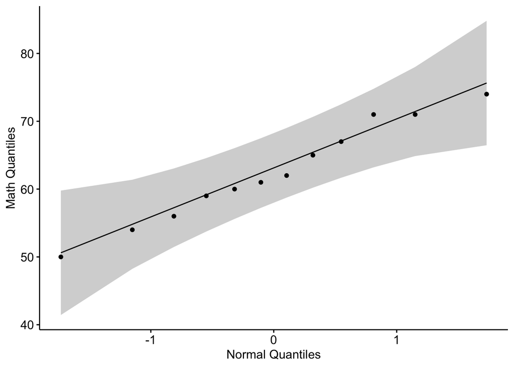

```r
ggqqplot(maths, ylab = "Math Quantiles", xlab="Normal Quantiles")
```

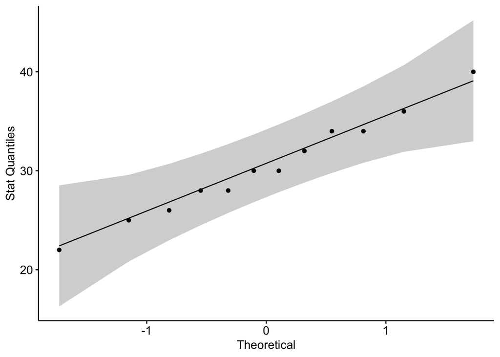

```r
ggqqplot(stat, ylab = "Stat Quantiles")
```

By the charts we can say that both datasets are close to a normal distribution, but we can’t assume that follows it.

To make sure its better to conduct a statistical normality test. So we will run *Shapiro-Wilk test* against the datasets.

For the Shapiro Wilk tests we apply the following formula:
$$W = \frac{(\sum a_ixi)^2}{\sum(x_i - \bar{x})^2}$$
If the test is non-significant $(p > 0.05)$ it tells us that the distribution of the sample is not significantly different from a normal distribution. If, however, the test is significant $(p < 0.05)$ then the distribution in question is significantly different from a normal distribution (non-normal).

```r
shapiro.test(maths)
```

```
##
##  Shapiro-Wilk normality test
##
## data:  maths
## W = 0.97402, p-value = 0.948
```

```r
shapiro.test(stat)
```

```
##
##  Shapiro-Wilk normality test
##
## data:  stat
## W = 0.9871, p-value = 0.9986
```

Because both p-values are significantly bigger than 0.05 (0.948, 0.9986) we can consider that both datasets follow a normal distribution.

For that we will use the method Pearson to calculate the correlation coefficient.

```r
cor.test(maths, stat, method='pearson')
```

```
##
##  Pearson's product-moment correlation
##
## data:  maths and stat
## t = 3.9885, df = 10, p-value = 0.002565
## alternative hypothesis: true correlation is not equal to 0
## 95 percent confidence interval:
##  0.3810636 0.9363950
## sample estimates:
##       cor
## 0.7835978
```

So because we got a coefficient of $0.7835978$ we can tell that exists a high correlation between maths ant statistics score.

You see the correlation by observing the scatter plot between the two.

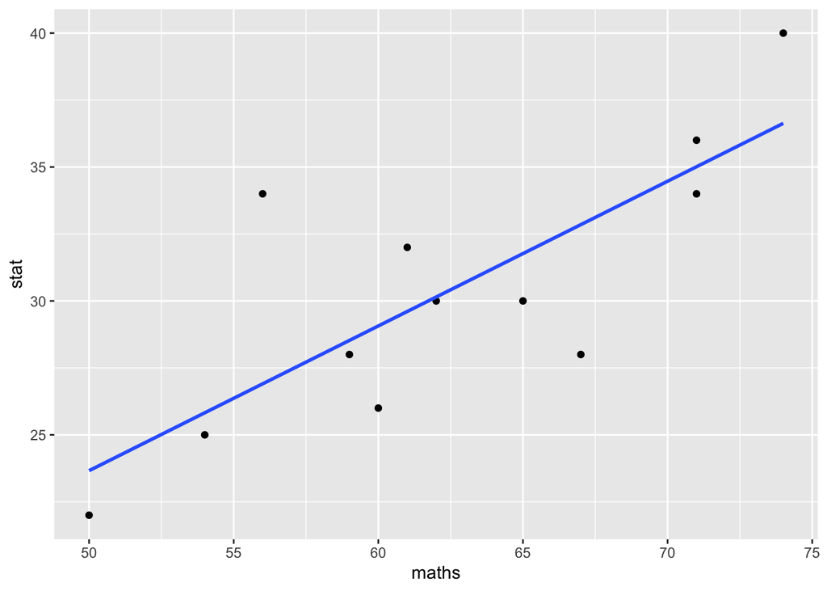

```r
ggplot(data = scoreSet, aes(x = maths, y = stat))  +
  geom_point() +
  geom_smooth(formula = y ~ x, method = "lm", se = FALSE)
```

# Question 4 [5 marks]

[Note: Save the read dataset in a variable called heartdisease. Do not change the variable name. For ex: heardisease <- read.csv(“heartdisease.data”)]

Consider given dataset heartdisease.csv. Write code to do the following.

1. Assess the following variables for normality. [2 marks]
- Cholesterol (Chol)
- Blood Pressure (RestBP)
- MaxHR
2. Choose the test you think is correct based on your these variables
- choose either Pearson, Spearman / Kendall to investigate the following: [3 marks]
- Relationship between cholesterol and blood pressure;
- Relationship between cholesterol and old peak.

## Answer 4

First we load the dataset

```r
heartdisease <- read.csv("heartdisease.csv")
```

Next we will test the three variables for normality with the Shapiro-Wilk test.

```r
shapiro.test(heartdisease$Chol)
```

```
##
##  Shapiro-Wilk normality test
##
## data:  heartdisease$Chol
## W = 0.94725, p-value = 5.912e-09
```

```r
shapiro.test(heartdisease$RestBP)
```

```
##
##  Shapiro-Wilk normality test
##
## data:  heartdisease$RestBP
## W = 0.96655, p-value = 1.802e-06
```

```r
shapiro.test(heartdisease$MaxHR)
```

```
##
##  Shapiro-Wilk normality test
##
## data:  heartdisease$MaxHR
## W = 0.97645, p-value = 6.996e-05
```

All the three values are bellow 0.05 so the data significantly deviate from a normal distribution. For skew data we use Spearman/Kendal correlation.

For the relationship between cholesterol and blood pressure

```r
cor.test(heartdisease$Chol, heartdisease$RestBP, method = "spearman", exact = FALSE)
```

```
##
##  Spearman's rank correlation rho
##
## data:  heartdisease$Chol and heartdisease$RestBP
## S = 4006524, p-value = 0.018
## alternative hypothesis: true rho is not equal to 0
## sample estimates:
##       rho
## 0.1358367
```

So the Correlation Coefficient value of 0.1358367 represents a *weak positive monotonic correlation*.

The probability value is 0.018 and is less than 0.05 $\alpha$ threshold meaning that the observation is statistically significant.

So we assume that theres is a *weak correlation between cholesterol and blood pressure*. You can see the verify in the next plot.

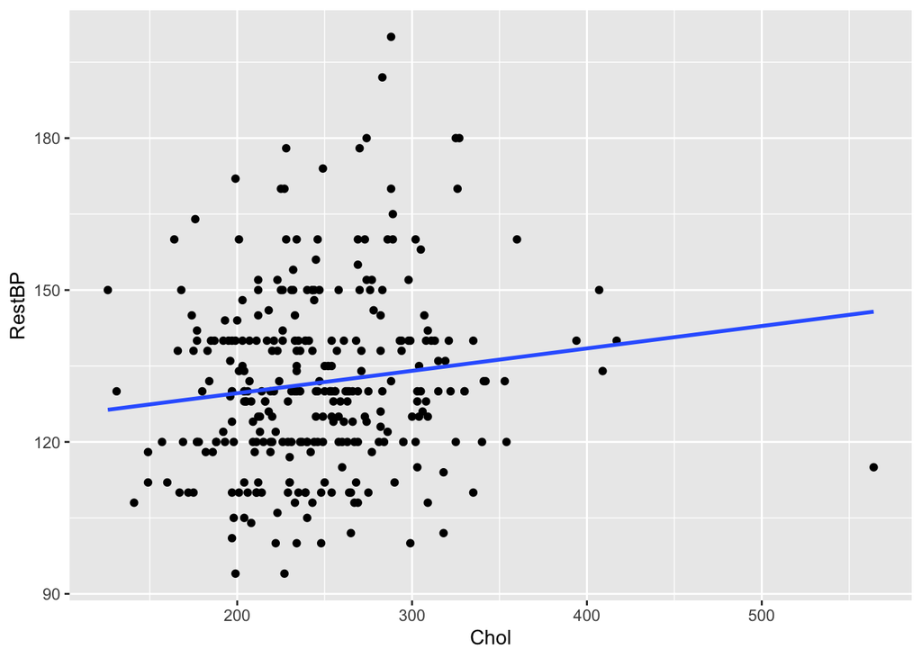

```r
ggplot(data = heartdisease, aes(x = Chol, y = RestBP))  +
  geom_point() +
  geom_smooth(formula = y ~ x, method = "lm", se = FALSE)
```

Relationship ▪ Relationship between cholesterol and old peak

First let’t test the `Oldpeak` variable for normality.

```r
shapiro.test(heartdisease$Oldpeak)
```

```
##
##  Shapiro-Wilk normality test
##
## data:  heartdisease$Oldpeak
## W = 0.84418, p-value < 2.2e-16
```

Again we get a really low p-value suggesting that we are not talking about data not normally distributed. Again we will use the spearman test.

```r
cor.test(heartdisease$Chol, heartdisease$Oldpeak, method = "spearman", exact = FALSE)
```

```
##
##  Spearman's rank correlation rho
##
## data:  heartdisease$Chol and heartdisease$Oldpeak
## S = 4477004, p-value = 0.5513
## alternative hypothesis: true rho is not equal to 0
## sample estimates:
##        rho
## 0.03435936
```

The coefficient rho is 0.03435936 that represents a positive weak correlation as presented in the chart.

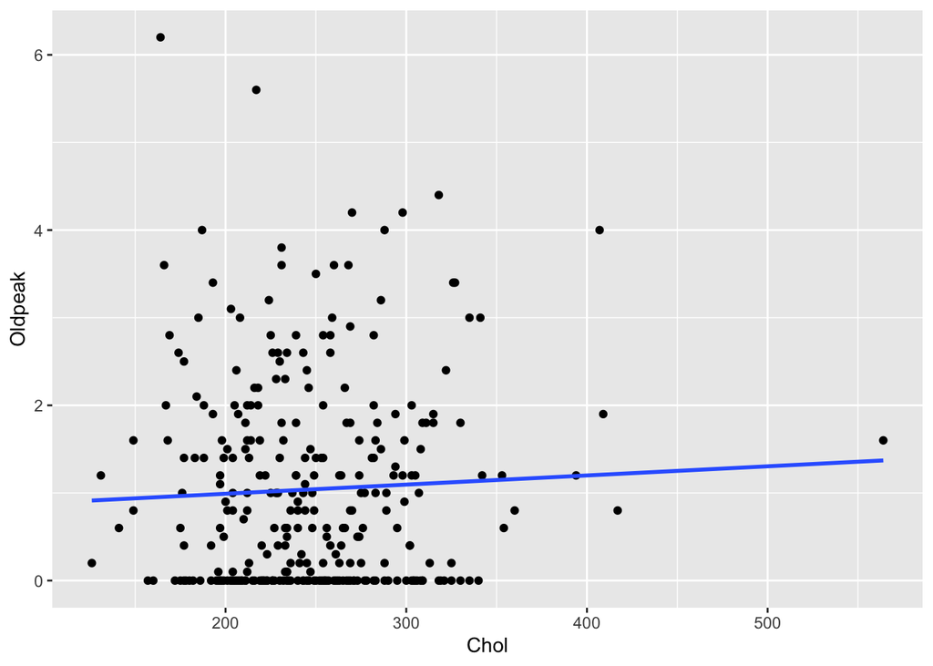

```r
ggplot(data = heartdisease, aes(x = Chol, y = Oldpeak))  +
  geom_point() +
  geom_smooth(formula = y ~ x, method = "lm", se = FALSE)
```

But because the p-value is above the assumed significant level $\alpha = 0.05$ we *fail to reject the null hypothesis*. We conclude that is no correlation/relationship between the cholesterol and old peak for a significance level of $0.05$.

# Question 5 [2 marks]

Investigate whether there are differences between people who survive hepatitis and those who do not in each of the following variables.

- BILIRUBIN;
- SGOT.

[Note: Save the read dataset in a variable called hepatitis. Do not change the variable name. For ex: `hepatitis <- read.csv("hepatitis.data")`. Dataset is available https://archive.ics.uci.edu/ml/datasets/Hepatitis. Use the code below to add header.]

```
#To add headers
colnames(hepatitis) <- c("Class", "AGE", "SEX",
"STEROID", "ANTIVIRALS", "FATIGUE", "MALAISE",
"ANOREXIA", "LIVER BIG", "LIVER FIRM", "SPLEN
PALPABLE", "SPIDERS", "ASCITES",
"VARICES","BILIRUBIN","ALK PHOSPHATE",
"SGOT","ALBMIN", "PROTIME", "HISTOLOGY")
```

## Answer 5

First we need to load the data and add the headers.

```r
hepatitis <- read.csv("hepatitis.data", quote="", na.strings = "?")

colnames(hepatitis) <- c(
  "Class",
  "AGE",
  "SEX",
  "STEROID",
  "ANTIVIRALS",
  "FATIGUE",
  "MALAISE",
  "ANOREXIA",
  "LIVER BIG",
  "LIVER FIRM",
  "SPLEN PALPABLE",
  "SPIDERS",
  "ASCITES",
  "VARICES",
  "BILIRUBIN",
  "ALK PHOSPHATE",
  "SGOT",
  "ALBMIN",
  "PROTIME",
  "HISTOLOGY")
```

First thing that we will do is look at the data and the structure

```r
str(subset(hepatitis, select = c("Class", "BILIRUBIN", "SGOT")))
```

```
## 'data.frame':    154 obs. of  3 variables:
##  $ Class    : int  2 2 2 2 2 1 2 2 2 2 ...
##  $ BILIRUBIN: num  0.9 0.7 0.7 1 0.9 NA 1 0.7 1 1.3 ...
##  $ SGOT     : int  42 32 52 200 28 NA NA 48 120 30 ...
```

So `class` is refered as int but in fact its a categorical class. We need to transform it in a character class type.

```r
hepatitis<- transform(hepatitis, Class = as.character(Class))
str(subset(hepatitis, select = c("Class", "BILIRUBIN", "SGOT")))
```

```
## 'data.frame':    154 obs. of  3 variables:
##  $ Class    : chr  "2" "2" "2" "2" ...
##  $ BILIRUBIN: num  0.9 0.7 0.7 1 0.9 NA 1 0.7 1 1.3 ...
##  $ SGOT     : int  42 32 52 200 28 NA NA 48 120 30 ...
```

Now lets take a look at the data:

```r
head(subset(hepatitis, select = c("Class", "BILIRUBIN", "SGOT")))
```

```
##   Class BILIRUBIN SGOT
## 1     2       0.9   42
## 2     2       0.7   32
## 3     2       0.7   52
## 4     2       1.0  200
## 5     2       0.9   28
## 6     1        NA   NA
```

`Class` is a categorical variable that determines if the patient died or not:

- 1 = DIE
- 2 = LIVE It also does not has Missing values.

`BILIRUBIN` is a continuous variable that represents a yellowish pigment that is made during the breakdown of red blood cells. It has 6 missing values.

`SGOT` is a integer variable that represents SGOT is a protein made by the liver cells. It also has 4 missing values.

```r
sum(is.na(hepatitis$BILIRUBIN))
```

```
## [1] 6
```

```r
sum(is.na(hepatitis$SGOT))
```

```
## [1] 4
```

Now that we analyze the data we can describe it:

```r
table(hepatitis$Class)
```

```
##
##   1   2
##  32 122
```

```r
psych::describe(hepatitis$BILIRUBIN)
```

```
##    vars   n mean   sd median trimmed  mad min max range skew kurtosis  se
## X1    1 148 1.43 1.22      1    1.17 0.44 0.3   8   7.7 2.82     9.59 0.1
```

```r
psych::describe(hepatitis$SGOT)
```

```
##    vars   n  mean    sd median trimmed   mad min max range skew kurtosis   se
## X1    1 150 86.35 89.78     58   68.74 41.51  14 648   634 3.11    13.25 7.33
```

So we have a sample where 32 individuals died and 122 survived.

Both `BILLRUBIN` and `SGOT` variables are positively skewed with a high kurtosis so it it suggest a non-normal distribution.

Now we will split the variables in survived not survived:

```r
hepatitis.BILLRUBIN.die = hepatitis[hepatitis$Class == 1, c("BILIRUBIN")]
hepatitis.BILLRUBIN.survived = hepatitis[hepatitis$Class == 2, c("BILIRUBIN")]

hepatitis.SGOT.die = hepatitis[hepatitis$Class == 1, c("SGOT")]
hepatitis.SGOT.survived = hepatitis[hepatitis$Class == 2, c("SGOT")]
```

```r
shapiro.test(hepatitis.BILLRUBIN.survived)
```

```
##
##  Shapiro-Wilk normality test
##
## data:  hepatitis.BILLRUBIN.survived
## W = 0.68454, p-value = 1.394e-14
```

```r
shapiro.test(hepatitis.SGOT.survived)
```

```
##
##  Shapiro-Wilk normality test
##
## data:  hepatitis.SGOT.survived
## W = 0.67244, p-value = 5.344e-15
```

```r
ks.test(hepatitis.BILLRUBIN.die, "pnorm")
```

```
##
##  Asymptotic one-sample Kolmogorov-Smirnov test
##
## data:  hepatitis.BILLRUBIN.die
## D = 0.68261, p-value = 1.444e-12
## alternative hypothesis: two-sided
```

```r
ks.test(hepatitis.SGOT.die, "pnorm")
```

```
##
##  Asymptotic one-sample Kolmogorov-Smirnov test
##
## data:  hepatitis.SGOT.die
## D = 1, p-value < 2.2e-16
## alternative hypothesis: two-sided
```

As we can notice none of the datasets follow a normal distribution. Because we are running a test for 2 groups of a continuous variable with skewed data we choose the* Mann-Whitney U test to compare* the following groups:

- hepatitis.BILLRUBIN.survived against hepatitis.BILLRUBIN.die
- hepatitis.SGOT.survived against hepatitis.SGOT.die

```r
wilcox.test(hepatitis.BILLRUBIN.die, hepatitis.BILLRUBIN.survived)
```

```
##
##  Wilcoxon rank sum test with continuity correction
##
## data:  hepatitis.BILLRUBIN.die and hepatitis.BILLRUBIN.survived
## W = 2710, p-value = 6.521e-06
## alternative hypothesis: true location shift is not equal to 0
```

```r
wilcox.test(hepatitis.SGOT.die, hepatitis.SGOT.survived)
```

```
##
##  Wilcoxon rank sum test with continuity correction
##
## data:  hepatitis.SGOT.die and hepatitis.SGOT.survived
## W = 2048, p-value = 0.2448
## alternative hypothesis: true location shift is not equal to 0
```

In the first hepatitis.BILLRUBIN.die and hepatitis.BILLRUBIN.survived we have p-value of 6.521e-06 so we reject the null hypothesis concluding that there is difference between then.

For the second case hepatitis.SGOT.die and hepatitis.SGOT.survived we have a p-value = 0.2448 that is bigger than the $\alpha$ level of 0.05. So we fail to reject the null hypothesis and say that there is no statistical significant evidence that hepatitis.SGOT.die and hepatitis.SGOT.survived are different.

# Question 6 [2 marks]

Formulate a hypothesis by considering ALK PHOSPHATE levels and hepatitis histology by considering hepatitis dataset. Mention whether you accept or reject the hypothesis.

## Answer 6

Before we formulate an hypothesis we need to understand the dataset and the variables

The alkaline phosphatase (ALP) test measures how much alkaline phosphatase you have in your blood. Alkaline phosphatase is an enzyme found throughout your body. But it is mainly in your liver, bone, kidney, and digestive tract. Conditions such as liver cancer, cirrhosis, and hepatitis can also cause ALP levels to rise. This value is our dataset is represented as a range between 26 and 295 (incluse) it also has missing 29 values.

Liver biopsy (LB) is the gold standard method for assessment of liver histology. So we can identify if we have liver histology via biopsy. So in our dataset we have a categorical variable that indicates if we histology was indentified in the liver or not. The values that the dataset provides are:

- 1 no;
- 2 yes.

Considering this we assume that what we want here is to verify is when alkaline phosphatase ALP increases (ALK PHOSPHATE levels) this is related with the hepatitis histology detection or not.

Now looking at the data we have the following results:

```r
psych::describe(hepatitis$ALK.PHOSPHATE)
```

```
##    vars   n   mean    sd median trimmed   mad min max range skew kurtosis   se
## X1    1 125 105.49 51.68     85   99.14 35.58  26 295   269 1.31     1.76 4.62
```

```r
table(hepatitis$HISTOLOGY)
```

```
##
##  1  2
## 84 70
```

We can tell that HISTOLOGY is a relatively well distribute about its categories (84 no and 70 yes) and the ALK PHOSPHATE has a positive skew meaning a right-skewed distribution (mean higher than the median) and a peaked kurthosis.

So we consider the following null hypothesis:

- There is no difference in ALK PHOSPHATE levels between different histology categories of hepatitis.
- There is a difference in ALK PHOSPHATE levels between different histology categories of hepatitis.

Because we are talking about the same population a good measure to verify is the mean (because we are talking about a continuous variable I think that) is more appropriate.

- $H_0$: There is no difference in the ALK.PHOSPHATE mean if histology is either true or false.
- $H_a$: There is difference in the ALK.PHOSPHATE mean if histology is either true or false.

The Significance Level established for the test will be $\alpha = 0.05$

So we will performa a two-tailed test.

Now as the previous exercise we will split the `ALK.PHOSPHATE` between the `HISTOLOGY` categories:

```r
hepatitis.ALK.PHOSPHATE.NO_HISTOLOGY <- hepatitis[hepatitis$HISTOLOGY == 1, c("ALK.PHOSPHATE")]
hepatitis.ALK.PHOSPHATE.HISTOLOGY <- hepatitis[hepatitis$HISTOLOGY == 2, c("ALK.PHOSPHATE")]
```

Samples bigger than 50 so we go to Kolmogorov-Smirnov test to test if the samples follow a normal distribution.

```r
ks.test(hepatitis.ALK.PHOSPHATE.NO_HISTOLOGY, "pnorm")
```

```
##
##  Asymptotic one-sample Kolmogorov-Smirnov test
##
## data:  hepatitis.ALK.PHOSPHATE.NO_HISTOLOGY
## D = 1, p-value < 2.2e-16
## alternative hypothesis: two-sided
```

```r
ks.test(hepatitis.ALK.PHOSPHATE.HISTOLOGY, "pnorm")
```

```
##
##  Asymptotic one-sample Kolmogorov-Smirnov test
##
## data:  hepatitis.ALK.PHOSPHATE.HISTOLOGY
## D = 1, p-value < 2.2e-16
## alternative hypothesis: two-sided
```

We got two extreme low values so we reject the null hypothesis, so we can tell that the * hepatitis.ALK.PHOSPHATE.NO_HISTOLOGY and hepatitis.ALK.PHOSPHATE.HISTOLOGY does not follow a normal distribution*.

You can confirm this looking at the next QQ-Plots.

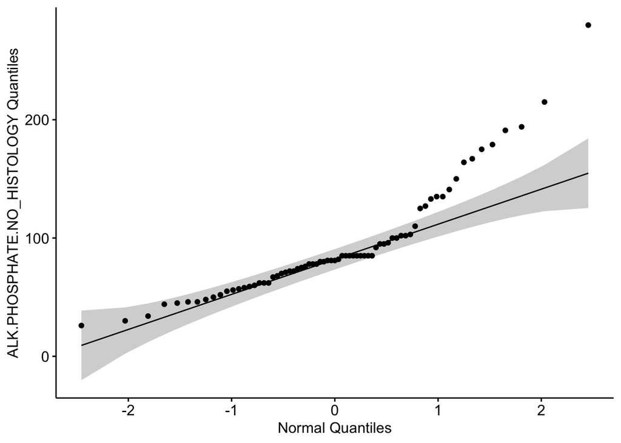

```r
ggqqplot(hepatitis.ALK.PHOSPHATE.NO_HISTOLOGY[!is.na(hepatitis.ALK.PHOSPHATE.NO_HISTOLOGY)], ylab = "ALK.PHOSPHATE.NO_HISTOLOGY Quantiles", xlab="Normal Quantiles")
```

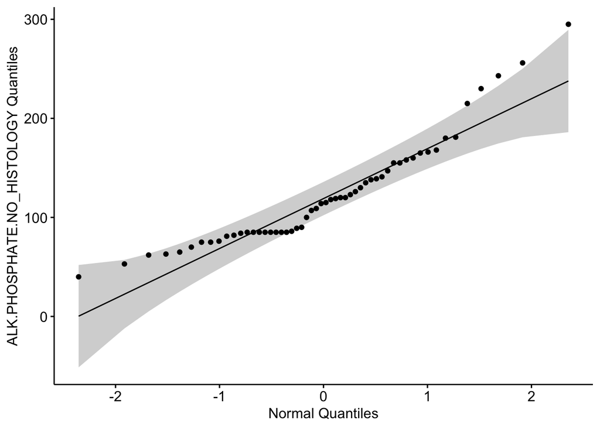

```r
ggqqplot(hepatitis.ALK.PHOSPHATE.HISTOLOGY[!is.na(hepatitis.ALK.PHOSPHATE.HISTOLOGY)], ylab = "ALK.PHOSPHATE.NO_HISTOLOGY Quantiles", xlab="Normal Quantiles")
```

So we have two independent groups with skewed data so we go with *Mann-Whitney U test*

```r
wilcox.test(hepatitis.ALK.PHOSPHATE.NO_HISTOLOGY, hepatitis.ALK.PHOSPHATE.HISTOLOGY)
```

```
##
##  Wilcoxon rank sum test with continuity correction
##
## data:  hepatitis.ALK.PHOSPHATE.NO_HISTOLOGY and hepatitis.ALK.PHOSPHATE.HISTOLOGY
## W = 1182.5, p-value = 0.0002492
## alternative hypothesis: true location shift is not equal to 0
```

To run the test we can use also the heaptitis dataset producing the same result.

```r
wilcox.test(ALK.PHOSPHATE ~ HISTOLOGY, data = hepatitis)
```

```
##
##  Wilcoxon rank sum test with continuity correction
##
## data:  ALK.PHOSPHATE by HISTOLOGY
## W = 1182.5, p-value = 0.0002492
## alternative hypothesis: true location shift is not equal to 0
```

Because the p-value is lower than the established $\alpha = 0.05$ we reject the null hypotesis and we can tell that *there is a relationship* between the ALK.PHOSPHATE and HISTOLOGY variables.

# Question 7 [2 marks]

Investigate the following questions by considering the Hepatitis dataset.

- Does the Bilirubin level impact the liver firm?
- Are there any differences in steroid level and hepatitis histology?

## Answer 7

For the this question we will do all the previous steps to answer.

We will also split this in question in 2 parts:

- Does the Bilirubin level impact the liver firm?
- Are there any differences in steroid level and hepatitis histology?

So for the first part we start analysing the variables. `LIVER.FIRM` is a categorical binary variable that has two values:

- 1 - no
- 2 - yes

It has 60 - no, 83 - yes and 11 missing data.

```r
table(hepatitis$LIVER.FIRM)
```

```
##
##  1  2
## 60 83
```

```r
sum(is.na(hepatitis$LIVER.FIRM))
```

```
## [1] 11
```

`BILIRUBIN` We already analise the data previously. It represents a continuous variable skewed. It has 6 missing values.

```r
summary(hepatitis$BILIRUBIN)
```

```
##    Min. 1st Qu.  Median    Mean 3rd Qu.    Max.    NA's
##    0.30    0.70    1.00    1.43    1.50    8.00       6
```

So we have 2 independent groups given by the categorical variable. We will use once again *Mann-Whitney U test*

```r
wilcox.test(hepatitis$BILIRUBIN ~ LIVER.FIRM, data = hepatitis)
```

```
##
##  Wilcoxon rank sum test with continuity correction
##
## data:  hepatitis$BILIRUBIN by LIVER.FIRM
## W = 2761, p-value = 0.08598
## alternative hypothesis: true location shift is not equal to 0
```

So we got a p-value of 0.08598 and we fail to reject a null hypothesis. So we can conclude that there is no relation between `BILIRUBIN` and `LIVER.FIRM` for one confidence-level at 0.05.

The second part of the question we have two categorical variables. The `HISTOLOGY` we already analyze previously. The `STEROID` level variable has two values:

- 1 - no (75 samples);
- 2 - yes (78 samples).

And has 1 missing value.

```r
table(hepatitis$STEROID)
```

```
##
##  1  2
## 75 78
```

```r
sum(is.na(hepatitis$STEROID))
```

```
## [1] 1
```

So we have two independent groups with two categorical variables. We will use the $\chi^2$ test.

```r
chisq.test(hepatitis$STEROID, hepatitis$HISTOLOGY)
```

```
##
##  Pearson's Chi-squared test with Yates' continuity correction
##
## data:  hepatitis$STEROID and hepatitis$HISTOLOGY
## X-squared = 1.0698, df = 1, p-value = 0.301
```